# Choice Reaction Time and Accuracy of the DRT

[Spencer Castro](http://spencercastro.com)

August 31, 2016

# Choice DRT Participant Summaries

20 participants responded to either the high **(1)**, low **(2)**, or both **(3)** intensities of light presented by the DRT. When responding to the high or low light, that intensity of light appeared 100% of the time. This is referred to as **mode** . Participants also either counted backwards by 3’s from a number produced by a random number generator between 100 and 1000 **(1)**, or they did not **(0)**. This is referred to as **load** .

```r
knitr::opts_chunk$set(fig.path='Figs/', fig.align='center',
                      warning=FALSE, message=FALSE, results='show')
```

```r
require(ggplot2)


rm(list=ls()); par(mfrow = c(1,1))
setwd("~/Desktop/Studies/ModelingStudypart2/Results")

my.axis.font<-theme(axis.title.x = element_text(size=18), axis.title.y = element_text(size=18),
                    axis.text.x = element_text(size=18), axis.text.y = element_text(size=18),
                    plot.title=element_text(size=18,face="bold"),
                    legend.title=element_text(size=14),legend.text=element_text(size=14))

'%ni%' <- Negate('%in%')

# READ DATA ------------------------

fulldata<-read.csv("output2raw.csv", header=TRUE)


cleandata <- subset(fulldata, rt > 200 & rt < 5000 & mode != 0)

cleandata$subid <- factor(cleandata$subid)
cleandata$load <- factor(cleandata$load)
cleandata$mode <- factor(cleandata$mode)
cleandata$rt <- as.integer(cleandata$rt)


require(plyr)
cleandata$response <- revalue(cleandata$response, c("wrong"=0, "correct"=1))

cleandata$response <- droplevels(cleandata$response)
cleandata$mode <- droplevels(cleandata$mode)

cleandata$response <- as.numeric(levels(cleandata$response))[cleandata$response]

clean.mean <- aggregate(list(cleandata$rt,cleandata$response),
                        by = list(as.factor(cleandata$mode),as.factor(cleandata$load),
                                  as.factor(cleandata$stimulus),cleandata$subid),
                        FUN = 'mean')

colnames(clean.mean) <- c("mode","load","stimulus","subid","rt","acc")

clean.mean$acc <- ((clean.mean$acc)*100)
```

## Full data and cleaned data comparisons

```r
full_counts <- ftable(1~subid+mode+load, data=fulldata)
clean_counts <- ftable(1~subid+mode+load, data=cleandata)
```

Mean number of trials per block for the full dataset compared to the cleaned dataset (RT’s greater than 200 and less than 5000). There are 6 blocks with 3 DRT modes and 2 load levels. There are 2 blocks with just steering at the 2 load levels.

```r
mean(full_counts)
```

```
## [1] 190.55
```

```r
mean(clean_counts)
```

```
## [1] 189.5917
```

## Response Bias

Mean response accuracy for choice task **(3)** blocks by high **(1)** and low **(2)** DRT light stimulus intensities

```r
require(doBy)
stimcheck <- subset(cleandata, mode == 3)
summaryBy(response~load + mode + stimulus, data=stimcheck,FUN=c(mean,median,var), na.rm=TRUE)
```

```
##   load mode stimulus response.mean response.median response.var
## 1    0    3        1     0.7446184               1    0.1902549
## 2    0    3        2     0.7383838               1    0.1932708
## 3    1    3        1     0.6929735               1    0.2128696
## 4    1    3        2     0.7052298               1    0.2079906
```

It looks as if on average there is no meaningful response bias between the high **(1)** and low **(2)** DRT light stimulus intensities

### Individually though, there are some response biases.

For each participant, I calculated a difference score from their percent accuracy **(response.diff)** to the choice task **(3)** broken down by the difference between their accuracy to the high **(1)** and low **(2)** lights.

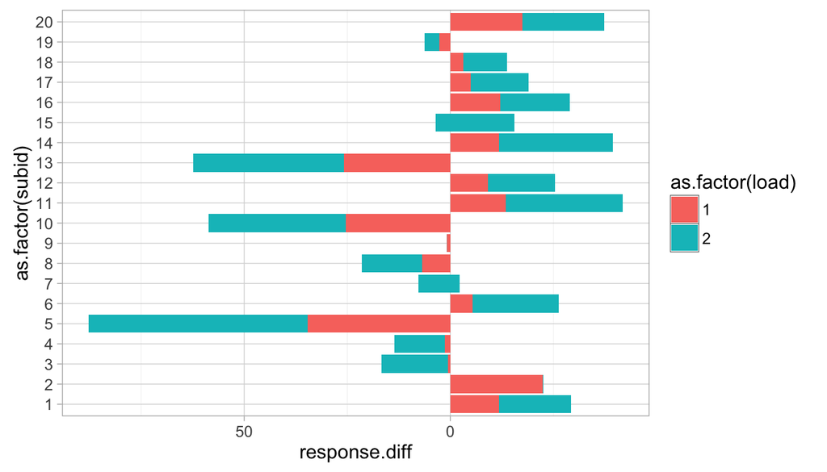

```r
stimcheck <- subset(cleandata, mode == 3)
bias <- summaryBy(response~ mode + subid + load + stimulus, data=stimcheck,FUN=c(mean,var), na.rm=TRUE)

bigbias <- ddply(bias, .(subid), transform, response.mean=(response.mean[stimulus == 1]-response.mean[stimulus == 2])*100)

colnames(bigbias) <- c("mode","subid","stimulus","load","response.diff","response.var")


myvars <- c("subid","load","response.diff")
bigbias <- bigbias[myvars]

bigbias <- unique(bigbias)

dev <- ggplot(data=bigbias,aes(x=as.factor(subid), y = response.diff, fill = as.factor(load))) +
  geom_bar(data = bigbias,
           stat = "identity") + scale_y_continuous(breaks=seq(-50,0,50),labels = abs(seq(-50,0,50))) +
  coord_flip() + theme_light()
dev
```

It’s nice to see that one light intensity was not consistently preferred between participants, but it did seem to be consistently preferred within participants.

## Plots of Means

### Reaction Time

This plot shows the expected pattern for RT’s of high **(1)** and low **(2)** lights, as well as the choice **(3)** RT’s, and the slower counting **(1)** compared to not counting **(0)** conditions.

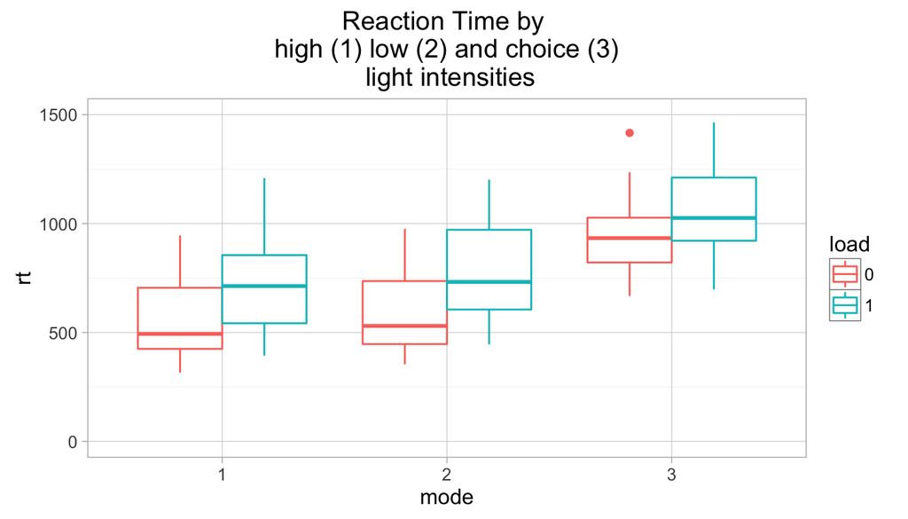

```r
qplot(mode, rt, data=clean.mean, geom="boxplot", color = load, ylim = c(0,1500)) +
  theme_light() + ggtitle("Reaction Time by \n high (1) low (2) and choice (3) \n light intensities")
```

```r
#Look at RT's by condition
```

### Accuracy

This plot shows the expected accuracy pattern for high **(1)** and low **(2)** lights, as well as the choice **(3)** task. There may be a more subtle effect of counting.

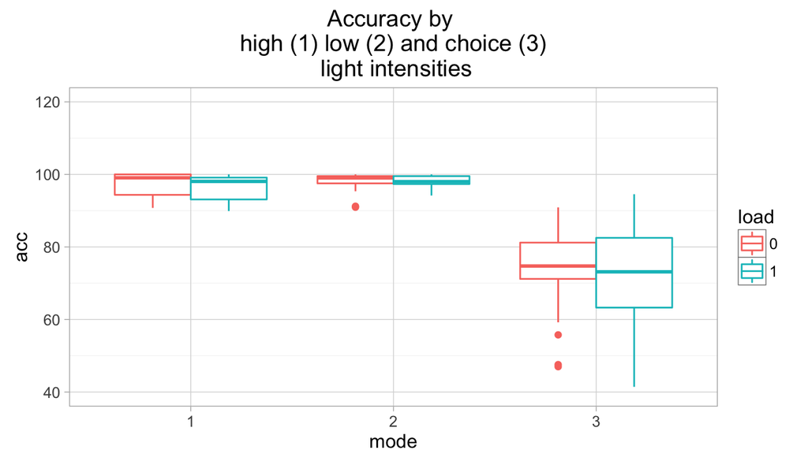

```r
qplot(mode, acc, data=clean.mean, geom="boxplot",color = load, ylim = c(40,120)) +
  theme_light() + ggtitle("Accuracy by \n high (1) low (2) and choice (3) \n light intensities")
```

```r
#Look at acc by condition

cleandata3 <- subset(clean.mean, mode == 3)
```

### Summaries of RT and accuracy by stimulus and load

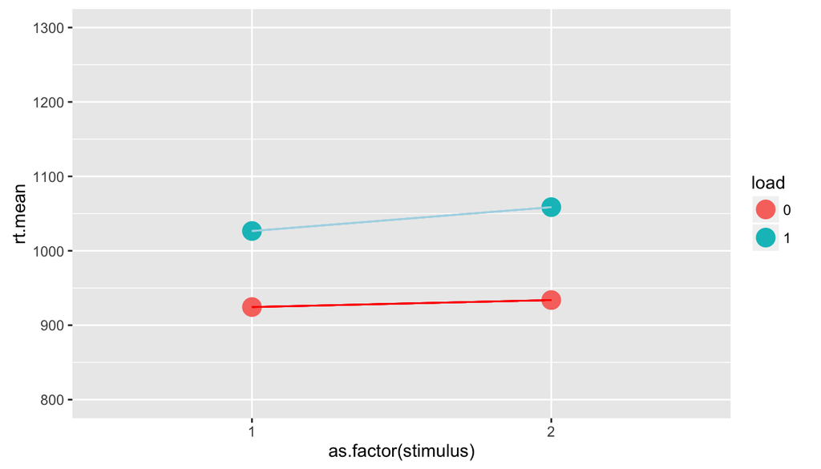

```r
dfrt <- summaryBy(rt~ as.factor(stimulus) + as.fator(load), data=stimcheck)
dfacc<- summaryBy(acc~ as.factor(stimulus) + as.fator(load), data=cleandata3)

ggplot(dfrt, aes(x = as.factor(stimulus), y=rt.mean, colour = load)) +
  geom_point(size=5) + ylim(800,1300) +
  geom_segment(aes(x=stimulus[1],y=rt.mean[1], xend=stimulus[3],yend=rt.mean[3]), color="red",data=dfrt) +
  geom_segment(aes(x=stimulus[2],y=rt.mean[2], xend=stimulus[4],yend=rt.mean[4]), color="light blue",data=dfrt)
```

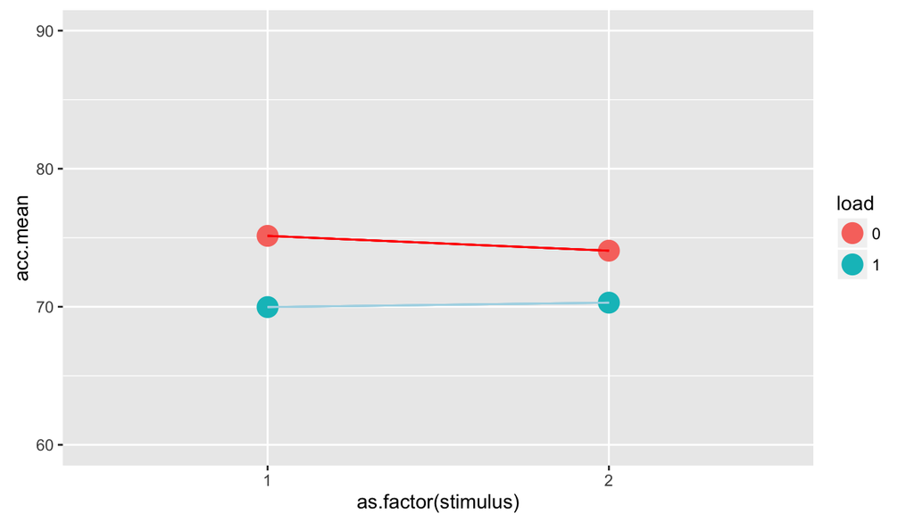

```r
ggplot(dfacc,aes(x = as.factor(stimulus), y=acc.mean, colour = load)) +
  geom_point(size=5) + ylim (60,90) +
  geom_segment(aes(x=stimulus[1],y=acc.mean[1], xend=stimulus[3],yend=acc.mean[3]), color="red",data=dfacc) +
  geom_segment(aes(x=stimulus[2],y=acc.mean[2], xend=stimulus[4],yend=acc.mean[4]), color="light blue",data=dfacc)
```

```r
# p <- qplot(mode, rt, data=cleandata3, geom="boxplot",color = load, ylim = c(800,1300)) +
#   theme_light() + ggtitle("RT by \n high (1) low (2) and choice (3) \n light intensities")
# p + facet_wrap(~subid + stimulus)
# head(cleandata3)
```

## Cumulative Distribution Functions

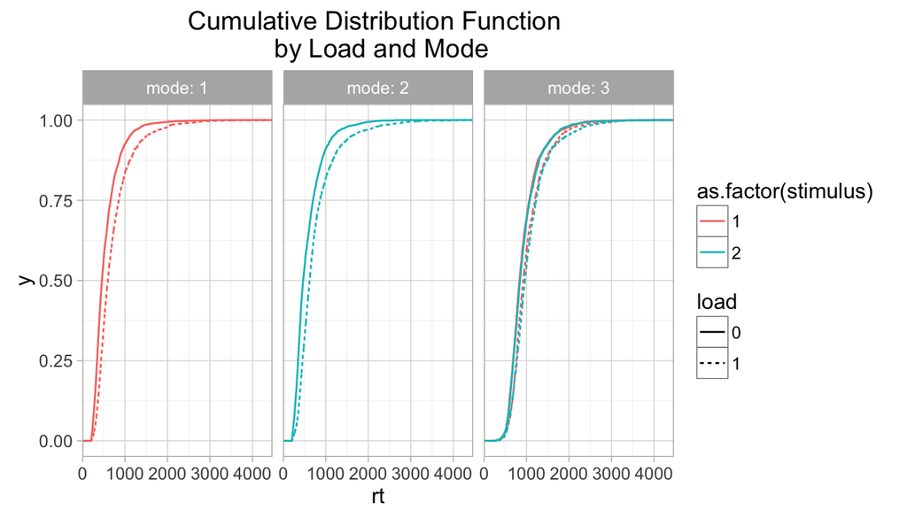

```r
p <- ggplot(cleandata, aes(rt, colour = as.factor(stimulus), linetype = load)) +
  stat_ecdf() + theme_light()
p + facet_wrap(~mode,ncol = 3, labeller = labeller(mode = label_both, load = label_both)) +
  ggtitle("Cumulative Distribution Function \n by Load and Mode")
```

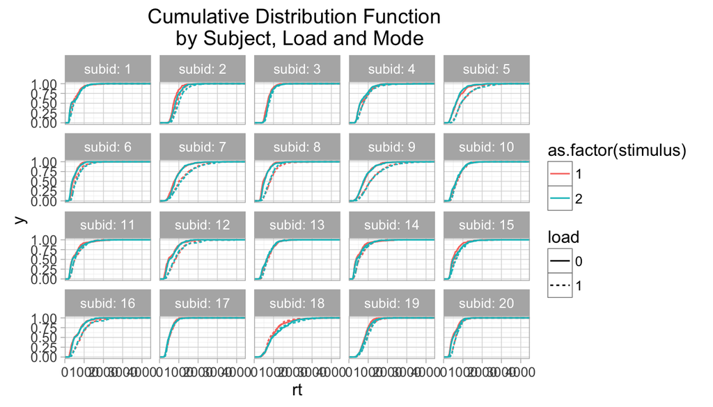

```r
p + facet_wrap(~subid, labeller = labeller(subid = label_both)) + theme_light() +
  ggtitle("Cumulative Distribution Function \n by Subject, Load and Mode")
```

*** In summary, I think that the data look as expected for the DRT, and it is ready to attempt a model. RT distributions for individuals are attached in the PDF file.